# Kepler IDA

- Show All Code
- Hide All Code
- View Source

Author

Aliaksandr Hubin

Published

2025-07-02

# 1 Load the libraries

```r
library(tidyverse)
library(DataExplorer)
```

# 2 IDA per 02.07.2025 version of the database

Firs the data will be updated from the most recent version of the database (OpenExoplanetCatalogue)

```r
data = read.csv("https://raw.githubusercontent.com/OpenExoplanetCatalogue/oec_tables/master/comma_separated/open_exoplanet_catalogue.txt")

head(data)
```

| name | binaryflag | mass | radius | period | semimajoraxis | eccentricity | periastron | longitude | ascendingnode | inclination | temperature | age | discoverymethod | discoveryyear | lastupdate | system_rightascension | system_declination | system_distance | hoststar_mass | hoststar_radius | hoststar_metallicity | hoststar_temperature | hoststar_age | list |
| --- | --- | --- | --- | --- | --- | --- | --- | --- | --- | --- | --- | --- | --- | --- | --- | --- | --- | --- | --- | --- | --- | --- | --- | --- |
| Kepler-1032 b | 0 | NA | 0.167 | 3.290118 | NA | NA | NA | NA | NA | NA | NA | NA | transit | 2016 | 16/05/10 | 19 19 43.4040 | +40 05 51.8400 | 683.854 | 0.770 | 0.71 | 0.16 | 4647 | NA | Confirmed planets |
| HD 154857 b | 0 | 2.24 | NA | 408.600000 | 1.291 | 0.46 | 57 | NA | NA | NA | 336 | NA | RV | 2004 | 14/01/25 | 17 11 15.7217 | -56 40 50.8706 | 64.200 | 1.718 | 2.31 | -0.31 | 5508 | NA | Confirmed planets |
| HD 154857 c | 0 | 2.58 | NA | 3452.000000 | 5.360 | 0.06 | 352 | NA | NA | NA | NA | NA | RV | 2014 | 14/01/25 | 17 11 15.7217 | -56 40 50.8706 | 64.200 | 1.718 | 2.31 | -0.31 | 5508 | NA | Confirmed planets |
| Kepler-994 b | 0 | NA | 0.143 | 1.151166 | NA | NA | NA | NA | NA | NA | NA | NA | transit | 2016 | 16/05/10 | 19 16 17.3254 | +47 24 25.3965 | 189.186 | 0.560 | 0.54 | -0.13 | 3934 | NA | Confirmed planets |
| Kepler-1350 b | 0 | NA | 0.225 | 4.496860 | NA | NA | NA | NA | NA | NA | NA | NA | transit | 2016 | 16/05/10 | 19 13 00.1410 | +46 40 46.5233 | 343.926 | 0.550 | 0.53 | -0.06 | 3827 | NA | Confirmed planets |
| Kepler-1350 c | 0 | NA | 0.154 | 1.766789 | NA | NA | NA | NA | NA | NA | NA | NA | transit | 2016 | 16/05/10 | 19 13 00.1410 | +46 40 46.5233 | 343.926 | 0.550 | 0.53 | -0.06 | 3827 | NA | Confirmed planets |

The data has 5414 observations over 25 variables.

```r
DataExplorer::plot_str(data = data)
```

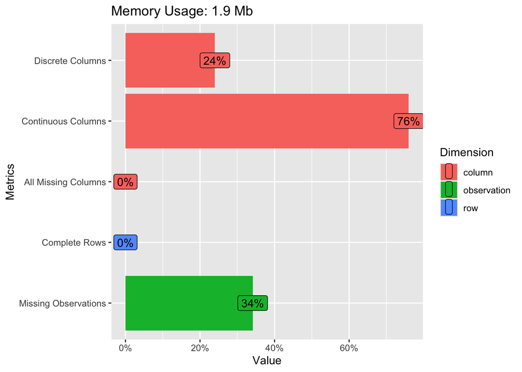

```r
DataExplorer::plot_intro(data = data)
```

Item missingness is described below

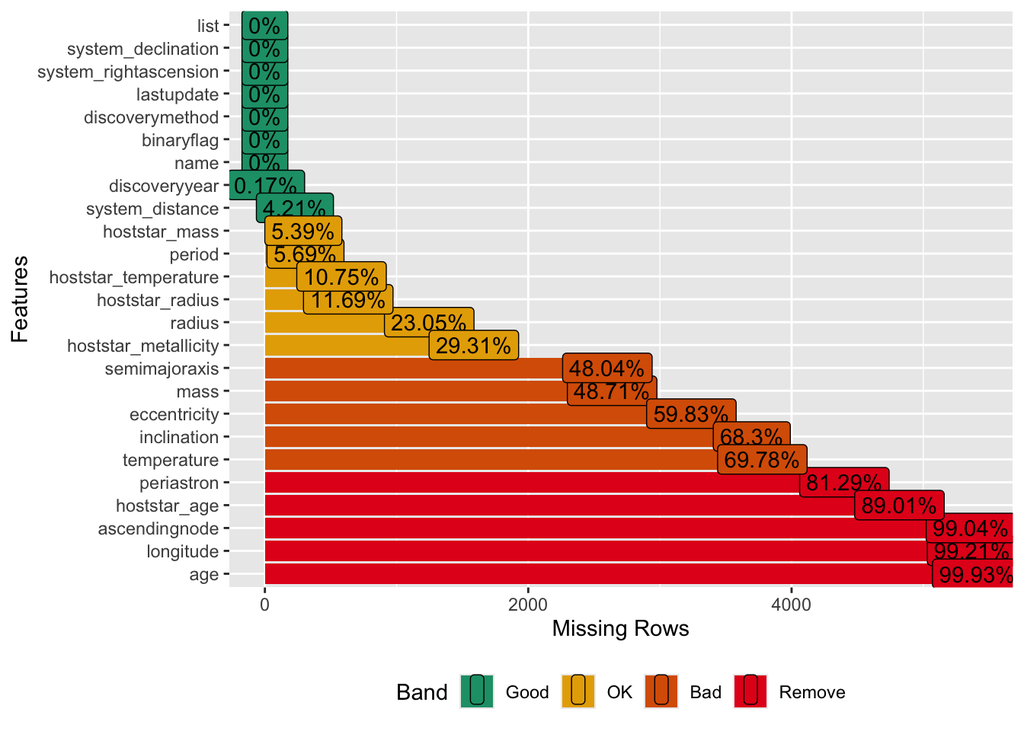

```r
DataExplorer::plot_missing(data = data)
```

We shall keep data with less than 60% of missing values and further remove planetary system specific variables and irrelevant for the analysis ones such as last-update, list, name, and discovery method. We assume missingness at random at hence observation units with missing data in any predictor variable or the dependent variable are removed.

```r
data <- data %>% select(semimajoraxis,mass, radius, period, eccentricity, hoststar_mass, hoststar_radius, hoststar_metallicity,hoststar_temperature,binaryflag) %>% na.omit()
```

Univariate distributions of all predictors and the dependent variables are produced below

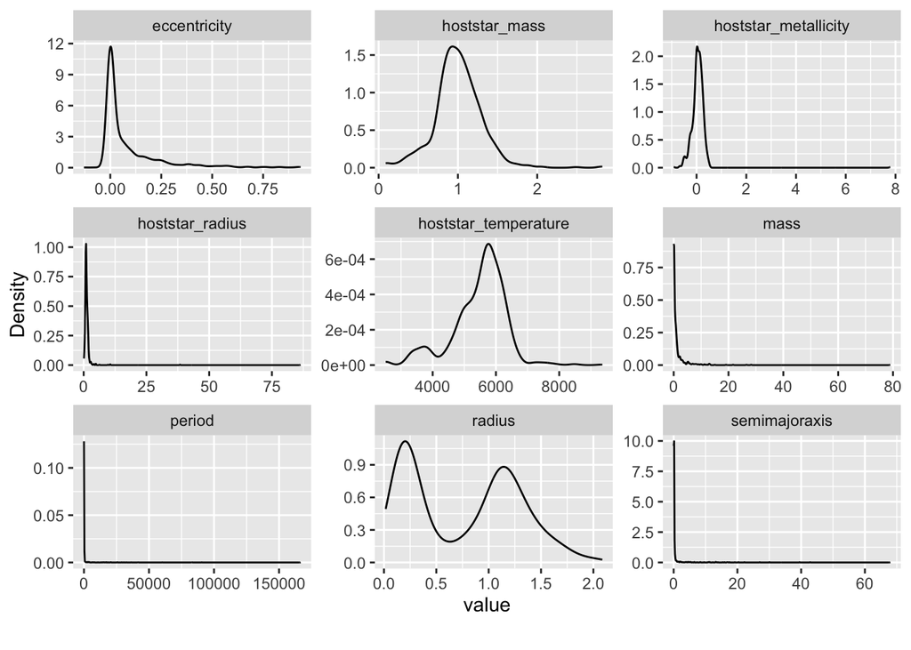

```r
DataExplorer::plot_density(data,nrow = 3,ncol = 3)
```

Same on the log scale

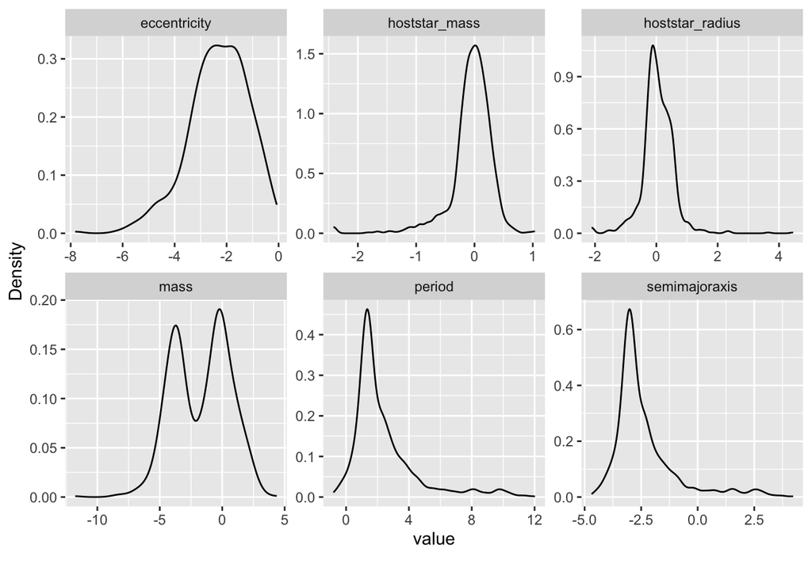

```r
DataExplorer::plot_density(log(data[,c("eccentricity","mass","period","semimajoraxis","hoststar_radius","hoststar_mass")]),nrow = 2,ncol = 3)
```

A matrix of Spearman correlations is produced below

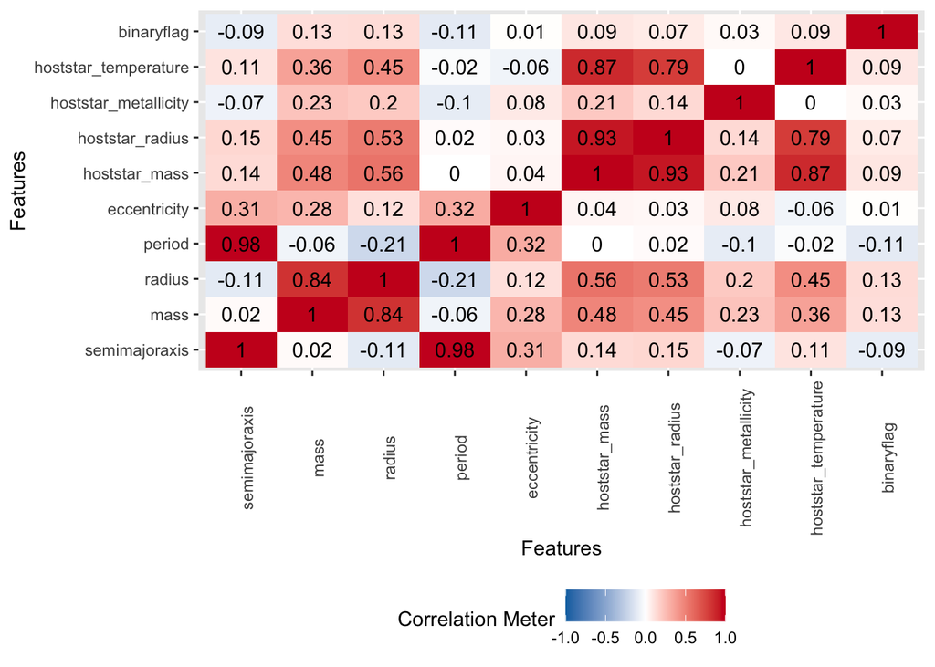

```r
DataExplorer::plot_correlation(data,type = "continuous",cor_args = list(use = "pairwise.complete.obs", method = "spearman"))
```

# 3 Splitting into the training and hold out test sets and saving

The data set was split into training and test data set. 300 randomly chosen planets are kept for evaluation.

```r
summary(data)
```

```
 semimajoraxis           mass              radius            period
 Min.   : 0.00916   Min.   : 0.00001   Min.   :0.01644   Min.   :     0.45
 1st Qu.: 0.04328   1st Qu.: 0.02541   1st Qu.:0.22626   1st Qu.:     3.35
 Median : 0.06010   Median : 0.27300   Median :0.85600   Median :     5.32
 Mean   : 0.78890   Mean   : 1.27930   Mean   :0.76944   Mean   :  1047.36
 3rd Qu.: 0.13000   3rd Qu.: 1.05700   3rd Qu.:1.19000   3rd Qu.:    18.36
 Max.   :67.96000   Max.   :79.00000   Max.   :2.08500   Max.   :166510.00
  eccentricity      hoststar_mass   hoststar_radius  hoststar_metallicity
 Min.   :-0.12929   Min.   :0.089   Min.   : 0.121   Min.   :-0.92000
 1st Qu.: 0.00000   1st Qu.:0.840   1st Qu.: 0.820   1st Qu.:-0.06000
 Median : 0.00380   Median :1.000   Median : 1.020   Median : 0.06000
 Mean   : 0.08658   Mean   :1.001   Mean   : 1.309   Mean   : 0.05242
 3rd Qu.: 0.10938   3rd Qu.:1.173   3rd Qu.: 1.400   3rd Qu.: 0.18100
 Max.   : 0.93369   Max.   :2.820   Max.   :86.400   Max.   : 7.79000
 hoststar_temperature   binaryflag
 Min.   :2516         Min.   :0.00000
 1st Qu.:5078         1st Qu.:0.00000
 Median :5645         Median :0.00000
 Mean   :5472         Mean   :0.05538
 3rd Qu.:6000         3rd Qu.:0.00000
 Max.   :9360         Max.   :2.00000
```

```r
set.seed(1)
te.ind <- sample.int(n = 939,size = 300,replace = F)
data.train = data[-te.ind,]
data.test = data[te.ind,]

saveRDS(data.train,file = "train.RDS")
saveRDS(data.test,file = "test.RDS")
```

### 3.0.1